# Vector-virus networks: Identifying target-genes for experimental validation

Supplementary for Kakenhi grant application

Nurit Eliash

8/24/2021

The analysis is based on the outputs of “varroa-virus-networks.Rmd”, in the meta-transcriptomic analysis on [GitHub web-page](https://github.com/nurit-eliash/varroa-virus-networks). All analyses can be reproduced directly using the input files available.

This mark down document starts from the second step of the network analysis, when we correlate the varroa modules to viruses’ load, in order to detect interesting modules.

### Load libraries

```r
library("dplyr")
library("tidyverse")
library("vegan")
library("DESeq2")
library("ggfortify")
library("WGCNA")
options(stringsAsFactors = FALSE) # Allow multi-threading within WGCNA. This helps speed up certain calculations.
library("rmarkdown")
library("knitr") # for the markdown
library("kableExtra") # for creating a scrolling table
library("ggplot2") # for plotting
library("ape") # for mantel.test
library("Biostrings")
library("ggrepel") # for spreading text labels on the plot
library("scales") # for axis labels notation
library("GO.db") # for GO term annotation
library("reshape2")
library("RSQLite")
library("AnnotationDbi") # for GO term annotation
library("GSEABase")
library("GOstats")
library("maps") # for the map background
library("htmltools")
library("rgdal")
library("grid")
library("gridExtra")
library("GeneOverlap") # for making the overlapping genes
library("cluster")
library("rmdformats")
library("corrplot") # for virus-virus correlation
library("viridis")
library("hrbrthemes")
library("ggthemes")
library("RColorBrewer")
library("naniar")
knitr::opts_chunk$set(echo = TRUE)
setwd("/Users/nuriteliash/Documents/GitHub/varroa-virus-networks") #set the directory as the local GitHub local repository
```

### (2) Correlating modules to viral load

To test if the varroa modules interact with the different viruses it carries, we correlated the module eigengenes to the viruses’ load (log10TPM). We used Pearson correlation method and adjusted the p-values for multiple comparisons using the Benjamini–Hochberg method to control the false discovery rate (Benjamini and Hochberg 1995) (Fig 2b).

```r
# For correlating varroa modules to viral load, we gonna use the table of 15 viruses saved in chunk "viral correlation", in section "viral correlation matrix", and correlated these to the varroa modules eigengenes found in the previous chunk.

# First we load the two data:
load("/Users/nuriteliash/Documents/GitHub/varroa-virus-networks/results/viruses_load_15.rds")
# change the names of the viruses to match their common name in the literature:
viruses_load_15 <- viruses_load_15 %>%
  dplyr::rename("VOV-1" = "VOV_1", "ARV-2"= "ARV_2", "SBV"= "SV", "DWVb"="VDV1/DWVb")

load(file = "/Users/nuriteliash/Documents/GitHub/varroa-virus-networks/results/Varroa_modules_networkConstruction-auto.RData")
load(file = "/Users/nuriteliash/Documents/GitHub/varroa-virus-networks/results/for_modules.rds")

# Define numbers of genes and samples
nGenes = ncol(for_modules);
nSamples = nrow(for_modules)
# Recalculate MEs with color labels
MEs0 = moduleEigengenes(for_modules, moduleColors)$eigengenes
MEs = orderMEs(MEs0)

# correlate the modules eigengenes (MEs) with the viral load (viruses_load_15)
moduleTraitCor_66 = cor(MEs, viruses_load_15, use = "p") %>%
  as.matrix()
moduleTraitPvalue = corPvalueStudent(moduleTraitCor_66, nSamples)

### Controlling the false discovery rate: Benjamini–Hochberg procedure ###
# using p.adjust function, for all comparisons, 15 modules and 15 viruses (m=225).

# first make the p-value matrix into a dataframe
moduleTraitPvalue_0 <- as.data.frame(moduleTraitPvalue)

# then "gather" all the p-values, so they will apear in one column
longer_Pvalue <- moduleTraitPvalue_0 %>%
  rownames_to_column("module") %>%
  gather("virus", "pvalue", -module)

# now calculate the p.adjust for each p-value
Padjust <- p.adjust(longer_Pvalue$pvalue, method = "fdr")

# and add the column of adjusted pvalues
Padjust <- add_column(longer_Pvalue, Padjust)

# now spread it back
moduleTraitPadjust <- Padjust %>%
  dplyr::select(-pvalue) %>%
  group_by(virus) %>%
  pivot_wider(names_from = virus, values_from = Padjust)
moduleTraitPadjust <- column_to_rownames(moduleTraitPadjust, "module") %>%
  as.matrix()
```

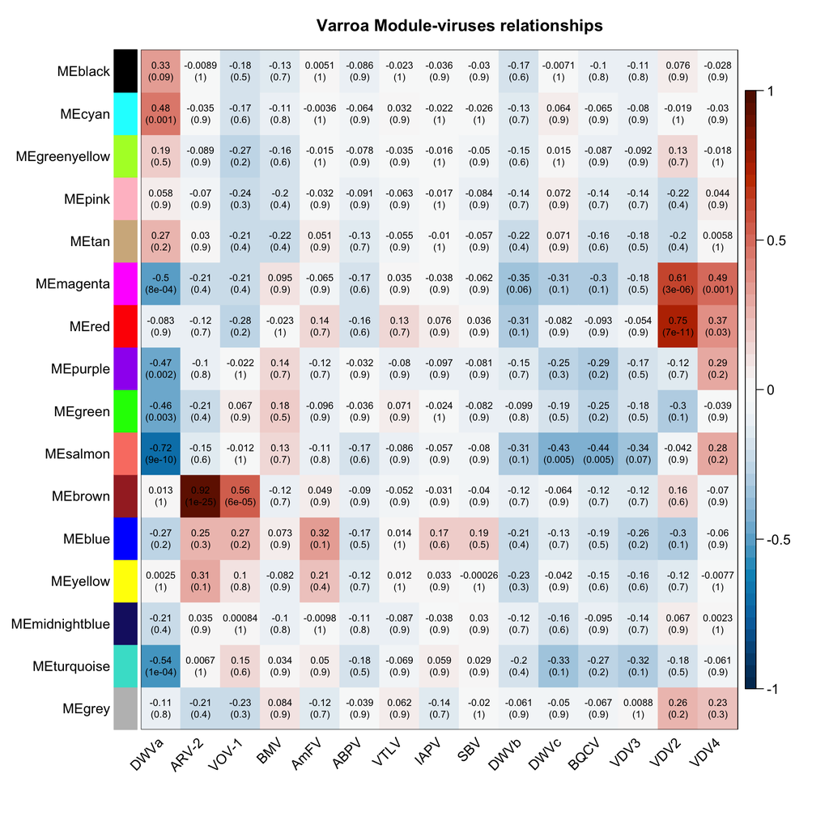

Figure 2b. Correlation between viruses’ loads and varroa modules (eigengenes). Viruses and modules are ordered according to hierarchical clustering; P-values of the Pearson coefficient are adjusted according to FDR-correction. In each cell, module-virus correlation values are given: Pearson correlation coefficient (up) and adjusted P-value.

```r
#  Display correlations and their adjusted p-values
textMatrix = paste(signif(moduleTraitCor_66, 2), "\n(",
                   signif(moduleTraitPadjust, 1), ")", sep = "");
dim(textMatrix) = dim(moduleTraitCor_66)
par(mar = c(6, 8.5, 3, 3));
# Display the correlation values within a heatmap plot
labeledHeatmap(Matrix = moduleTraitCor_66,
               xLabels = names(viruses_load_15),
               yLabels = names(MEs),
               #xLabelsAngle = 90,
               ySymbols = names(MEs),
               colorLabels = FALSE,
               colors = hcl.colors(n = 50, palette = "RdBu", alpha = NULL, rev = FALSE, fixup = TRUE),
               invertColors = TRUE,
               textMatrix = textMatrix,
               setStdMargins = FALSE,
               cex.text = 0.7,
               zlim = c(-1,1),
               main = paste("Varroa Module-viruses relationships"))
```

```r
# save the matrices for next analyses
#save(moduleTraitCor_66,moduleTraitPadjust_66, file = "/Users/nuriteliash/Documents/GitHub/varroa-virus-networks/results/moduleTraitCor_66.RData")
```

Correlating varroa modules eigengenes to their viruses’ loads (transcript per million, TPM), we found significant interactions between specific modules and viruses (Pearson correlation followed by Benjamini-Hochberg FDR-correction, P-adjust < 0.1, Fig 2b).

[output not shown]

### (3) Identifying important genes, ‘hub-genes’

The important genes were identified by accounting for two main parameters: Gene Significance and Module Membership (Langfelder and Horvath 2008). The Gene Significance is the correlation between the gene and the trait (the viral load), and the Module Membership is the correlation of the module eigengene and the gene expression. Genes with both high Gene Significance and Module Membership are referred as ‘hub-genes’, as they are expected to have high biological impact on many genes in the vector, and at the same time show high interaction with the viruses. Therefore, these genes may play a role in the vector-virus interaction, and are good candidates for later experimental validation.

#### load data

```r
load("/Users/nuriteliash/Documents/GitHub/varroa-virus-networks/results/viruses_load_15.rds")
# change the names of the viruses to match their common name in the literature:
viruses_load_15 <- viruses_load_15 %>%
  dplyr::rename("VOV-1" = "VOV_1", "ARV-2"= "ARV_2", "SBV"= "SV", "DWVb"="VDV1/DWVb")

load(file = "/Users/nuriteliash/Documents/GitHub/varroa-virus-networks/results/Varroa_modules_networkConstruction-auto.RData")
load(file = "/Users/nuriteliash/Documents/GitHub/varroa-virus-networks/results/for_modules.rds")

# Define numbers of genes and samples
nGenes = ncol(for_modules);
nSamples = nrow(for_modules)
# Recalculate MEs with color labels
MEs0 = moduleEigengenes(for_modules, moduleColors)$eigengenes
MEs = orderMEs(MEs0)
```

#### Calculating Gene Significanse (GS)

```r
# make a table with the Trait-significance ("GS") for each gene (which is its correlation coefficient, pearson)
geneTraitSignificance_66 = as.data.frame(cor(for_modules, viruses_load_15, use = "p"));
GSPvalue_66 = as.data.frame(corPvalueStudent(as.matrix(geneTraitSignificance_66), nSamples));

### Controlling the false discovery rate: Benjamini–Hochberg procedure ###
# using p.adjust function, for all comparisons, 15 modules and 15 viruses (m=225).

# first make the p-value matrix into a dataframe
GSPvalue_66_0 <- as.data.frame(GSPvalue_66)

# then "gather" all the p-values, so they will apear in one column
longer_Pvalue <- GSPvalue_66_0 %>%
  rownames_to_column("module") %>%
  gather("virus", "pvalue", -module)

# now calculate the p.adjust for each p-value
Padjust <- p.adjust(longer_Pvalue$pvalue, method = "fdr")

# and add the column of adjusted pvalues
Padjust <- add_column(longer_Pvalue, Padjust)

# now spread it back
GSPadjust_66 <- Padjust %>%
  dplyr::select(-pvalue) %>%
  group_by(virus) %>%
  pivot_wider(names_from = virus, values_from = Padjust)
GSPadjust_66 <- column_to_rownames(GSPadjust_66, "module")

#rename the col names by adding the initial "GS." for genesignificance, and "p.GS." for p-value.
names(geneTraitSignificance_66) = paste("GS.", names(viruses_load_15), sep="");
names(GSPadjust_66) = paste("pdj.GS.", names(viruses_load_15), sep="");
```

#### Calculating gene Module-membership (MM)

```r
# names (colors) of the modules
modNames = substring(names(MEs), 3)
# virusNames = substring(names(viruses_load_15), 1)

#make a table of the Module-membership ("MM") of each gene (which is its correlation coefficient, pearson)
geneModuleMembership_66 = as.data.frame(cor(for_modules, MEs, use = "p"));
MMPvalue_66 = as.data.frame(corPvalueStudent(as.matrix(geneModuleMembership_66), nSamples));

### Controlling the false discovery rate: Benjamini–Hochberg procedure ###
# using p.adjust function, for all comparisons, 15 modules and 15 viruses (m=225).

# first make the p-value matrix into a dataframe
MMPvalue_66_0 <- as.data.frame(MMPvalue_66)

# then "gather" all the p-values, so they will appear in one column
longer_Pvalue <- MMPvalue_66_0 %>%
    rownames_to_column("module") %>%
    gather("virus", "pvalue", -module)

# now calculate the p.adjust for each p-value
Padjust <- p.adjust(longer_Pvalue$pvalue, method = "fdr")

# and add the column of adjusted pvalues
Padjust <- add_column(longer_Pvalue, Padjust)

# now spread it back
MMPadjust_66 <- Padjust %>%
    dplyr::select(-pvalue) %>%
    group_by(virus) %>%
    pivot_wider(names_from = virus, values_from = Padjust)
MMPadjust_66 <- column_to_rownames(MMPadjust_66, "module")

#change the name of the columns to start with "MM" then the module name
names(geneModuleMembership_66) = paste("MM", modNames, sep="")
names(MMPadjust_66) = paste("padj.MM", modNames, sep="")
head(geneModuleMembership_66)
```

```
##               MMblack      MMcyan MMgreenyellow     MMpink       MMtan
## 111242787 -0.14044599 -0.19812593    -0.4135608 -0.4141333 -0.29802943
## 111242788  0.26152321  0.29427187     0.9611054  0.4391591  0.37283830
## 111242789  0.68338997  0.56916066     0.4510157  0.1380494  0.63220528
## 111242790  0.13382414 -0.02280418    -0.3030317 -0.3448149 -0.02403096
## 111242792  0.07567050 -0.04844946    -0.1586008 -0.3857588 -0.18983789
## 111242794 -0.06128537 -0.11877706    -0.2906744 -0.1798023 -0.07836970
##              MMmagenta       MMred    MMpurple     MMgreen   MMsalmon
## 111242787  0.076911952 -0.10431593 -0.03456385  0.35887494  0.5363371
## 111242788 -0.154521308 -0.03017150 -0.09156820 -0.41121969 -0.3516115
## 111242789 -0.119472669  0.03799934  0.06348479 -0.11115199 -0.1195930
## 111242790  0.072457907  0.25040880 -0.28254475 -0.04458923  0.2526848
## 111242792  0.590294923  0.89663229 -0.26034730 -0.10949824  0.1255675
## 111242794  0.006657925 -0.20985490  0.26495960  0.30649419  0.1713082
##               MMbrown     MMblue   MMyellow MMmidnightblue MMturquoise
## 111242787 -0.05178855  0.6825437  0.1297851     0.58023358  0.96000089
## 111242788 -0.13048456 -0.3974269 -0.1138791    -0.17257154 -0.48774686
## 111242789  0.17317856  0.3203665  0.7260186    -0.09671467 -0.16485499
## 111242790  0.27378469  0.8131316  0.4711770     0.65751107  0.78495393
## 111242792 -0.19180695  0.2409445  0.1748992     0.35161016  0.29069090
## 111242794  0.79747312  0.2655111  0.3142755    -0.21089701  0.07430784
##                 MMgrey
## 111242787 -0.318014845
## 111242788  0.005988542
## 111242789  0.079425840
## 111242790 -0.354382706
## 111242792  0.092059578
## 111242794 -0.022468718
```

```r
head(MMPadjust_66)
```

```
##           padj.MMblack  padj.MMcyan padj.MMgreenyellow padj.MMpink   padj.MMtan
## 111242787 3.952744e-01 2.052078e-01       2.369372e-03 0.002328393 4.071633e-02
## 111242788 7.964478e-02 4.382445e-02       4.970370e-35 0.001064916 7.375988e-03
## 111242789 3.273282e-09 4.828822e-06       7.179969e-04 0.404549252 1.261013e-07
## 111242790 4.211023e-01 9.118359e-01       3.679444e-02 0.014776744 9.069716e-01
## 111242792 6.757013e-01 8.003401e-01       3.273250e-01 0.005226829 2.279203e-01
## 111242794 7.415885e-01 4.825293e-01       4.700236e-02 0.257333734 6.636614e-01
##           padj.MMmagenta   padj.MMred padj.MMpurple padj.MMgreen padj.MMsalmon
## 111242787   6.702083e-01 5.453807e-01    0.86232205  0.010517555  2.403388e-05
## 111242788   3.418975e-01 8.814081e-01    0.60315666  0.002540383  1.256200e-02
## 111242789   4.795743e-01 8.470015e-01    0.73163694  0.515345271  4.790869e-01
## 111242790   6.904634e-01 9.583429e-02    0.05480257  0.817640599  9.234902e-02
## 111242792   1.554429e-06 1.490005e-22    0.08128305  0.522570367  4.543095e-01
## 111242794   9.745322e-01 1.757677e-01    0.07512781  0.034285700  2.841379e-01
##           padj.MMbrown  padj.MMblue padj.MMyellow padj.MMmidnightblue
## 111242787 7.852776e-01 3.497647e-09  4.371374e-01        2.696043e-06
## 111242788 4.343092e-01 3.782575e-03  5.035325e-01        2.800602e-01
## 111242789 2.781388e-01 2.563607e-02  8.307613e-11        5.798746e-01
## 111242790 6.432678e-02 2.859014e-15  3.522954e-04        2.270236e-08
## 111242792 2.222820e-01 1.114662e-01  2.726552e-01        1.256202e-02
## 111242794 2.627519e-14 7.442776e-02  2.919254e-02        1.732627e-01
##           padj.MMturquoise padj.MMgrey
## 111242787     1.133440e-34  0.02695799
## 111242788     1.881432e-04  0.97714449
## 111242789     3.057691e-01  0.65903622
## 111242790     1.344585e-13  0.01174802
## 111242792     4.698901e-02  0.60092845
## 111242794     6.819123e-01  0.91323376
```

#### Intramodular connectivity

```r
# We begin by calculating the intramodular connectivity for each gene. (In network literature, connectivity is often referred to as ”degree”.) The function intramodularConnectivity computes the whole network connectivity kTotal, the within module connectivity kWithin, kOut=kTotal-kWithin, and kDiff=kIn-kOut=2*kIN-kTotal

# calculate the correlation between each pair of genes
ADJ1_66 <- abs(cor(for_modules,use="p"))^6
# compute the different degrees of connectivity:
Alldegrees1_66 <- intramodularConnectivity(ADJ1_66, moduleColors)
head(Alldegrees1_66)
```

```
##               kTotal   kWithin      kOut      kDiff
## 111242787 1173.60009 960.22438 213.37571 746.848669
## 111242788   54.62946  23.70138  30.92809  -7.226707
## 111242789  107.34087  77.04244  30.29843  46.744006
## 111242790  711.13134 324.81821 386.31314 -61.494930
## 111242792  139.14413  39.69004  99.45409 -59.764049
## 111242794  226.48194 191.03668  35.44526 155.591418
```

```r
#save it
#save(Alldegrees1_66, file = "/Users/nuriteliash/Documents/GitHub/varroa-virus-networks/results/IntraModCon66.rds")
```

### (4) GO-term enrichment analysis for varroa modules

- Data based on analysis done in [Tehcer et al. (2019)](https://www.nature.com/articles/s42003-019-0606-0) [Maeva Techer github varroa-denovo-genomes project](https://github.com/MaevaTecher/varroa-denovo-genomes/blob/master/data/Positive%20selection/Vdesselected1511.csv)

```r
# load the
annot.vd <- read.csv("/Users/nuriteliash/Documents/GitHub/varroa-virus-networks/data/VdesGOready2.csv")

#Preparing the GO frame
annot.vd2 <- annot.vd %>%
  mutate(evidence = "IEA") %>%
  dplyr::select(go_id = GO.ids, evidence, gene = Gene.id)

head(annot.vd2)
```

```
##        go_id evidence      gene
## 1 GO:0005515      IEA 111242787
## 2 GO:0005576      IEA 111242789
## 3 GO:0008061      IEA 111242789
## 4 GO:0006030      IEA 111242789
## 5 GO:0005887      IEA 111242790
## 6 GO:0004872      IEA 111242790
```

```r
goFrame.vd <-GOFrame(annot.vd2, organism = "Vd")
goAllFrame.vd <-GOAllFrame(goFrame.vd)
gsc.vd <-GeneSetCollection(goAllFrame.vd, setType = GOCollection())

#Preparing the universe
universe.vd <- as.character(unique(annot.vd2$gene)) # there's a wired thing in the GSEAGOHyperGParams function, sometimes its required the universe to be "character".

# Preparing the gene set (list of genes in a module)
# change "black" to the name of the desired module, in the first line: [moduleColors=="black"], and in the final "write.csv(file = "GO_term_enrichment_**salmon**BP.csv")
ME <- names(for_modules)[moduleColors=="black"]
ME_df <- data.frame(gene = ME)
genes.vd <- unique(ME_df$gene)

params.vd <- GSEAGOHyperGParams(name = "Vd_GO_enrichment",
                                geneSetCollection = gsc.vd,
                                geneIds = genes.vd,
                                universeGeneIds = universe.vd,
                                ontology = "BP", # change with MF, CC to test all
                                pvalueCutoff = 0.05,
                                conditional = F,
                                testDirection = "over")

over.vd <- hyperGTest(params.vd)
over.vd
```

```
## Gene to GO BP  test for over-representation
## 321 GO BP ids tested (81 have p < 0.05)
## Selected gene set size: 39
##     Gene universe size: 5301
##     Annotation package: Based on a GeneSetCollection Object
```

```r
#summary(over.vd)

GO_enrich.vd <- as.data.frame(summary(over.vd)) %>%
  arrange(Pvalue)

# write.csv(GO_enrich.vd, file = "/Users/nuriteliash/Documents/GitHub/varroa-virus-networks/results/GO_term_black.csv")
```

All GO-terms of the significantly interacting modules are available as csv files, on the [github project](https://github.com/nurit-eliash/varroa-virus-networks/tree/master/results)

#### Identifying targeted genes for validation (silencing)

Next, we wish to identify the most interesting and important genes, that we will further validate using RNAi-silencing. these are ‘hub-genes’ in important modules.

**The target-genes should:**

- Belong to interesting module (module that significantly interacting with viral load and have relevant GO-terms)
- Have high Module-Membership (MM)
- Have high Gene-Trait Significance (GS)
- ? Have high intramodular connectivity (kWithin)

```r
# First, we gonna choose the interesting modules:
# Nine modules have significant interactions with the viral load, of at least one virus: 1, 3, 13, 5, 10, 6, 9, 14 and 7.
# of these modules, four have relevant GO-terms: 3, 6, 9 and 10.
# so, we gonna make a table with the gene, its module, MM, kWithin, GS, gene annotation

hub_genes_0 <- data.frame(
  moduleCol = moduleColors,
  geneModuleMembership_66,
  MMPadjust_66,
  Alldegrees1_66$kWithin,
  geneTraitSignificance_66,
  GSPadjust_66) %>%
  dplyr::select(c(moduleCol, MMpurple, padj.MMpurple, MMmagenta, padj.MMmagenta, MMred, padj.MMred, MMbrown, padj.MMbrown, Alldegrees1_66.kWithin, GS.DWVa, pdj.GS.DWVa, GS.ARV.2, pdj.GS.ARV.2, GS.VDV2, pdj.GS.VDV2)) %>%
  dplyr::filter(moduleCol %in% c("purple", "magenta", "red", "brown")) %>%
  dplyr::rename(kWithin = Alldegrees1_66.kWithin) %>%
  rownames_to_column("genes")

# add the modules' numbers
moduleNum <- as.character(c(0:15))
moduleCol <- as.character(c("grey", "turquoise", "blue", "brown", "yellow", "green", "red","black", "pink", "magenta", "purple", "greenyellow", "tan","salmon", "cyan","midnightblue"))
moduleCol_Num <- data.frame(moduleNum, moduleCol)

hub_genes_1 <- left_join(moduleCol_Num, hub_genes_0, by =  "moduleCol") %>%
  na.omit()

# add gene annotation:
# load the annotation file:
annot_varroa <- read_csv("/Users/nuriteliash/Documents/GitHub/varroa-virus-networks/data/annot_varroa.csv",
         col_types = cols_only("Protein Name" = col_character(), "Accession" = col_character(), "GeneID" = col_character())) %>%
  dplyr::rename(genes = GeneID)

hub_genes <- left_join(annot_varroa, hub_genes_1, by = "genes") %>%
  na.omit() %>%
  dplyr::select(c(genes, moduleCol, moduleNum, Accession, "Protein Name", kWithin, MMpurple, padj.MMpurple, MMmagenta, padj.MMmagenta, MMred, padj.MMred, MMbrown, padj.MMbrown, GS.DWVa, pdj.GS.DWVa, GS.ARV.2, pdj.GS.ARV.2, GS.VDV2, pdj.GS.VDV2))

head(hub_genes)
```

```
## # A tibble: 6 x 20
##   genes   moduleCol moduleNum Accession  `Protein Name`         kWithin MMpurple
##   <chr>   <chr>     <chr>     <chr>      <chr>                    <dbl>    <dbl>
## 1 111254… red       6         NW_019211… uncharacterized prote…    47.2   -0.174
## 2 111249… brown     3         NW_019211… chondroadherin-like p…   624.    -0.138
## 3 111249… brown     3         NW_019211… chondroadherin-like p…   624.    -0.138
## 4 111245… brown     3         NW_019211… spectrin alpha chain-…    23.7   -0.215
## 5 111251… brown     3         NW_019211… uncharacterized prote…   695.    -0.103
## 6 111250… brown     3         NW_019211… paramyosin-like isofo…   558.    -0.143
## # … with 13 more variables: padj.MMpurple <dbl>, MMmagenta <dbl>,
## #   padj.MMmagenta <dbl>, MMred <dbl>, padj.MMred <dbl>, MMbrown <dbl>,
## #   padj.MMbrown <dbl>, GS.DWVa <dbl>, pdj.GS.DWVa <dbl>, GS.ARV.2 <dbl>,
## #   pdj.GS.ARV.2 <dbl>, GS.VDV2 <dbl>, pdj.GS.VDV2 <dbl>
```

```r
# save the final table of the genes in modules 3, 6, 9 and 10
#write_csv(hub_genes, "/Users/nuriteliash/Documents/GitHub/varroa-virus-networks/results/hub_genes.csv")
```